# RMD output

# Output

## files_load_metabolon

*Log text:*  
loaded Metabolon file: sampledata.xlsx, sheet: OrigScale

## logging_tic

*Log text:*  
tic

# Preprocessing

## Part 1

### plots_sampleboxplot

*Log text:*  
sample boxplot, aes:

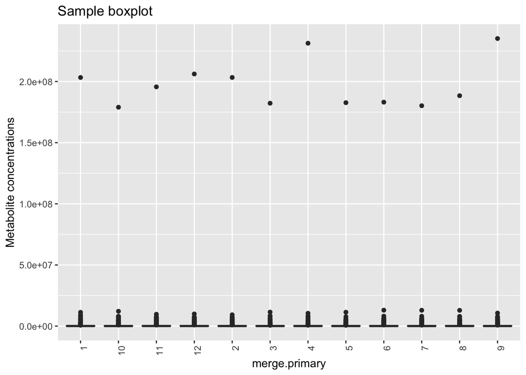

### plots_qc_missingness

*Log text:*  
missingness plots, missing values: 498 out of 2928 (17.01%)

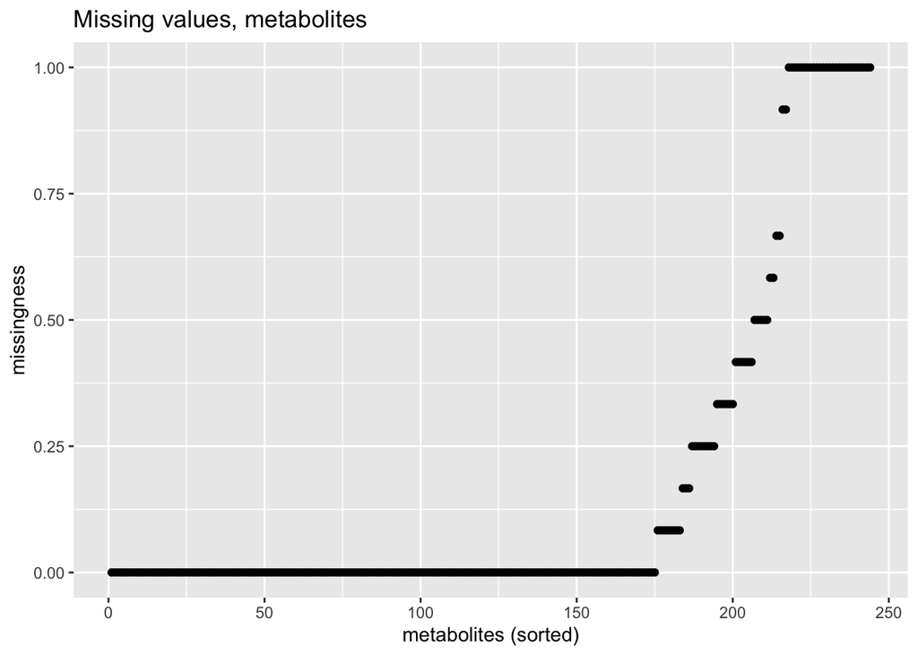

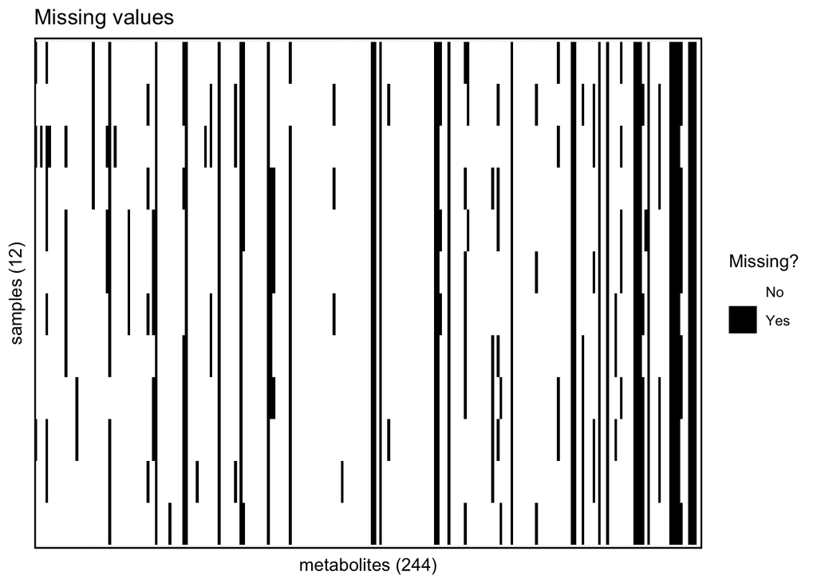

### pre_filtermiss

*Log text:*  
metabolites filtered, 20.00%, 58 of 244 removed

### pre_filtermiss

*Log text:*  
samples filtered, 10.00%, 0 of 12 removed

### pre_batch_median

*Log text:*  
median-scaling per batch in ‘BATCH_MOCK’

## Part 2

### pre_norm_quot

*Log text:*  
quotient normalization based on 12 reference samples and 186 variables: ~NULL

### plots_qc_dilutionplot

*Log text:*  
dilution factor plot, ‘num1’

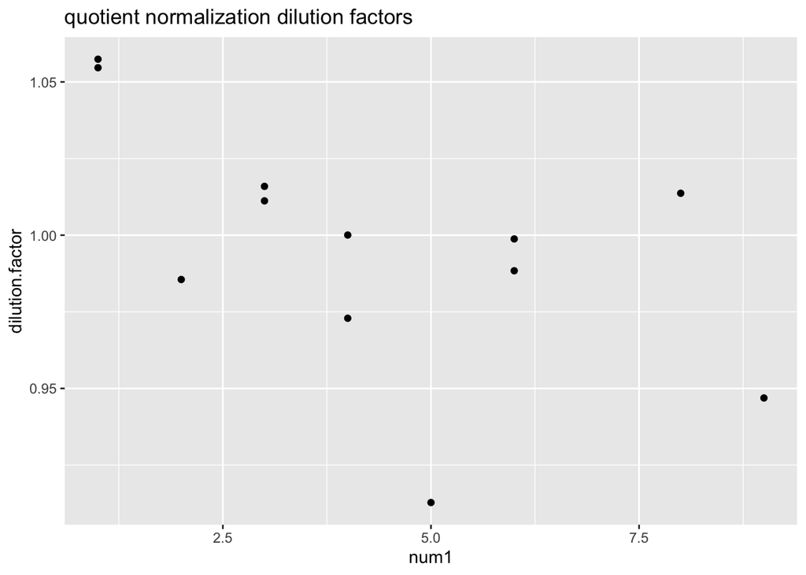

### plots_qc_dilutionplot

*Log text:*  
dilution factor plot, ‘Group’

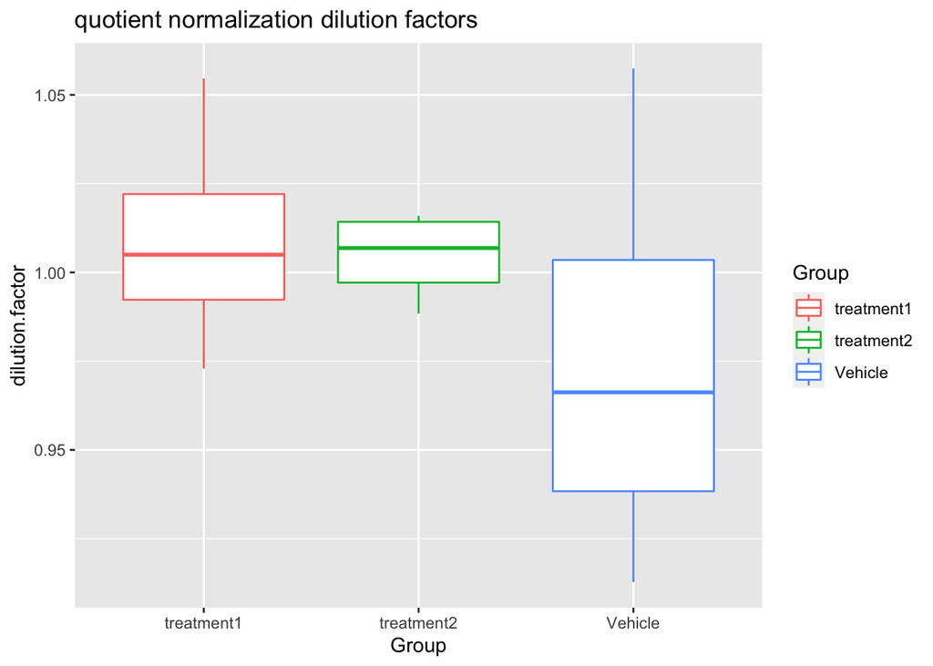

### pre_trans_log

*Log text:*  
log2

### pre_impute_knn

*Log text:*  
imputed via KNN

### pre_trans_scale

*Log text:*  
scaled, center=1, scale=1

### files_write_xls

*Log text:*  
Data exported to Excel file ‘out.xlsx’

### pre_outlier

*Log text:*  
flagged 8 univariate outliers

### plots_PCA

*Log text:*  
PCA, scores, labelby: CLIENT_IDENTIFIER, aes: color=GROUP_DESC

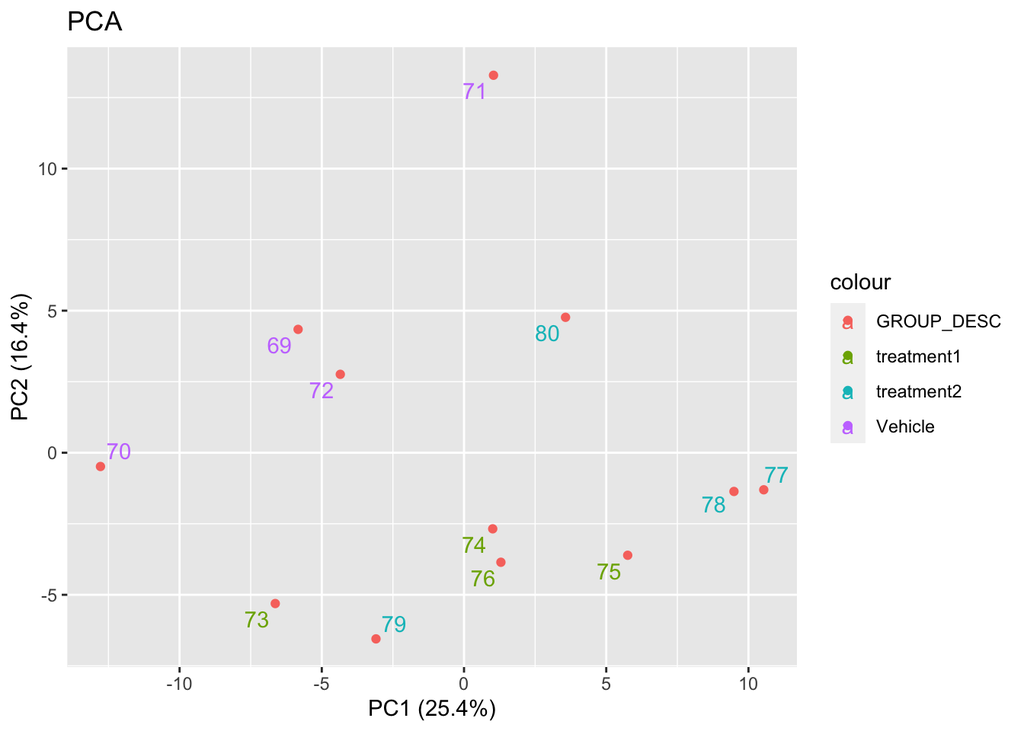

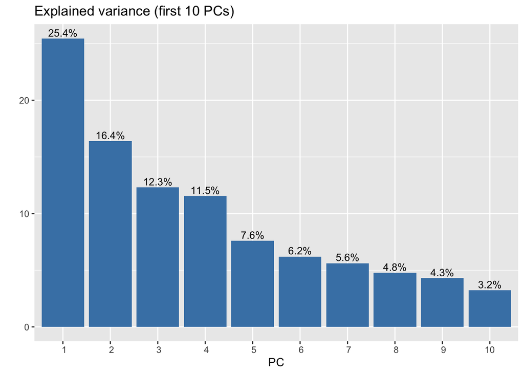

### plots_PCA

*Log text:*  
PCA, scores, labelby: CLIENT_IDENTIFIER, aes: color=outlier_univariate

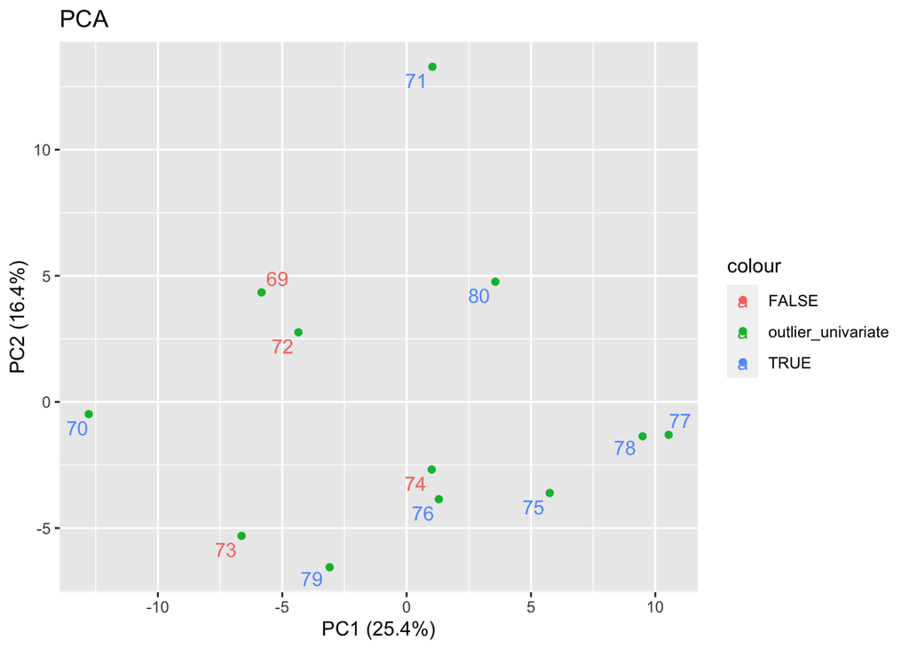

### plots_PCA

*Log text:*  
PCA, scores, labelby: CLIENT_IDENTIFIER, aes: color=GROUP_DESC

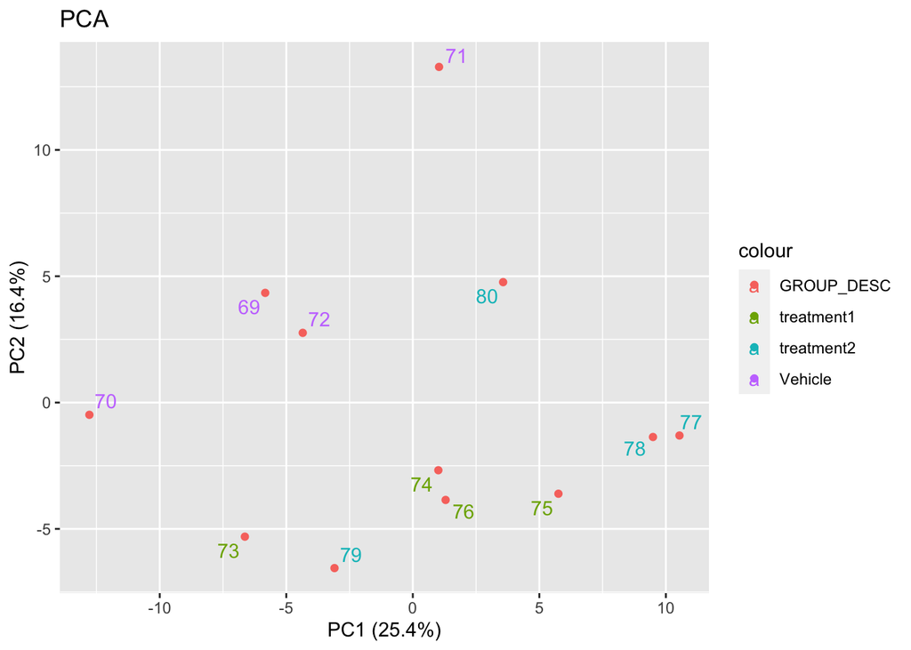

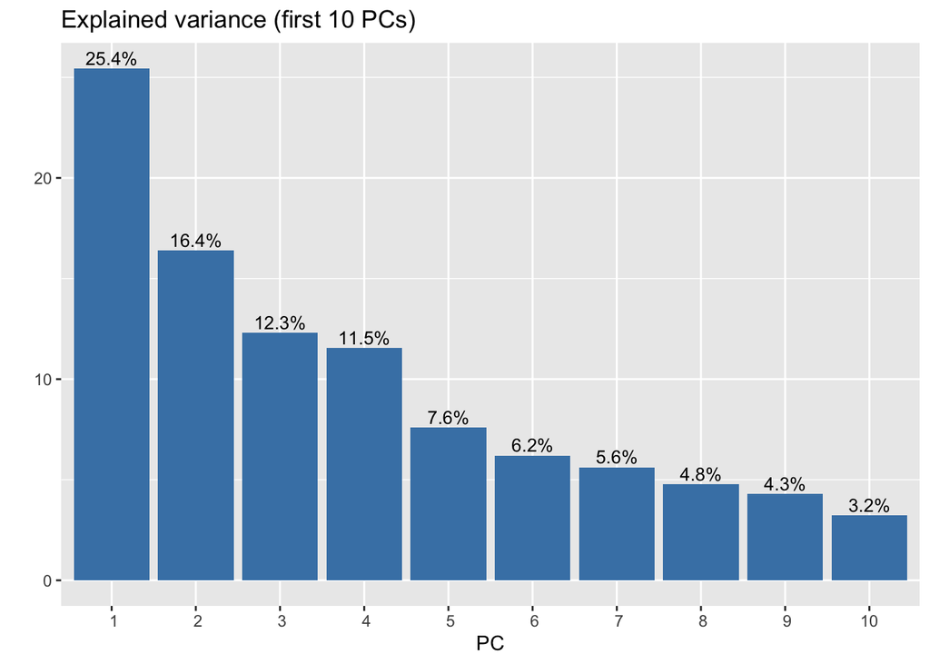

### plots_PCA

*Log text:*  
PCA, scores, labelby: CLIENT_IDENTIFIER, aes: color=GROUP_DESC

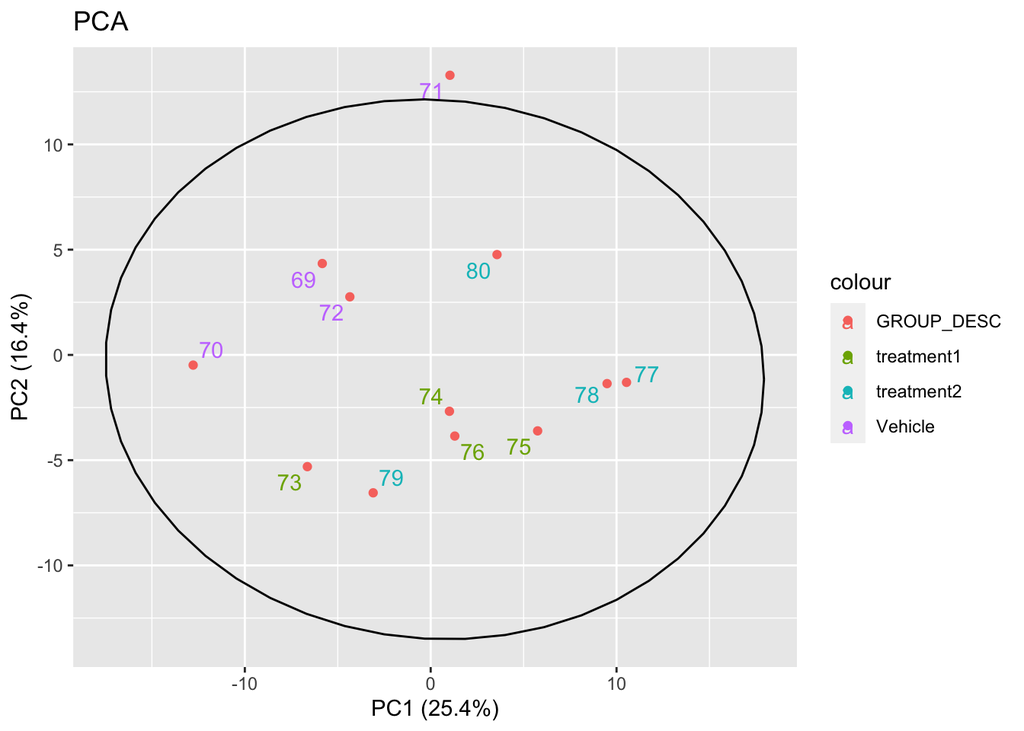

### plots_PCA

*Log text:*  
PCA, scores, labelby: , aes:

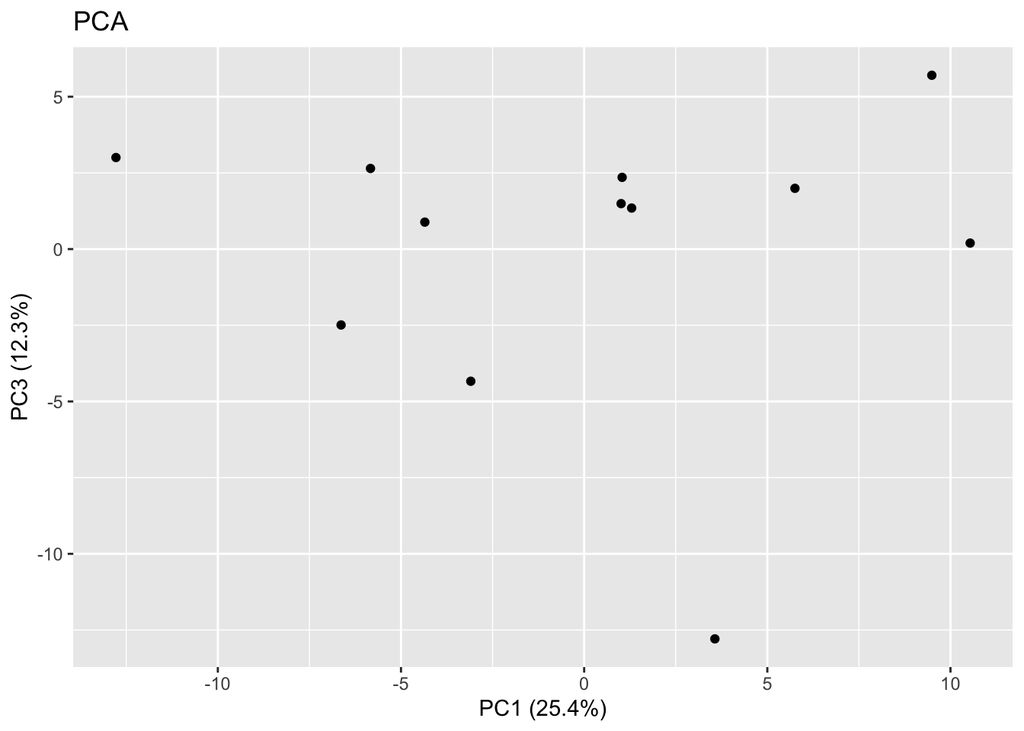

### plots_PCA

*Log text:*  
PCA, loadings, labelby: , aes:

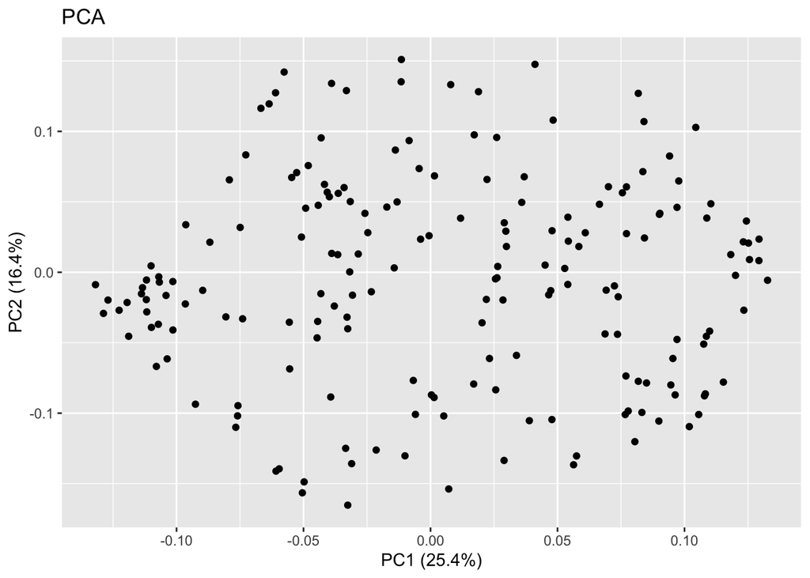

### plots_PCA

*Log text:*  
PCA, loadings, labelby: , aes:

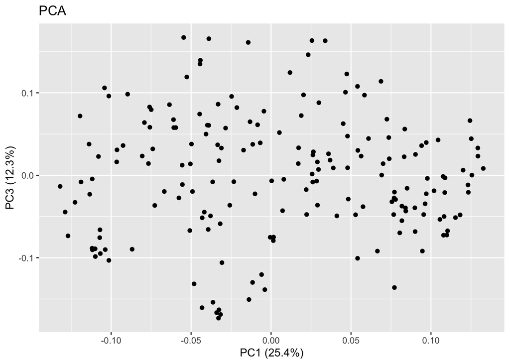

### plots_PCA

*Log text:*  
PCA, loadings, labelby: name, aes:

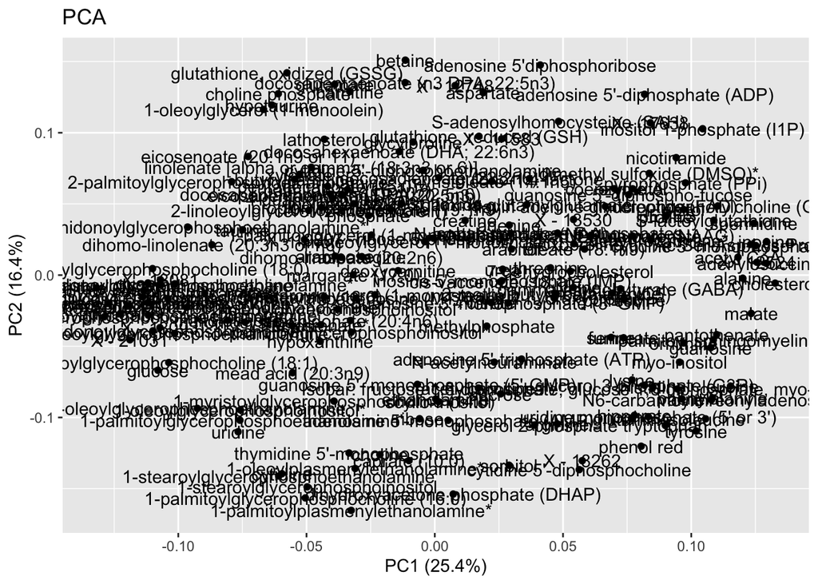

### plots_PCA

*Log text:*  
PCA, loadings, labelby: name, aes: color=SUPER_PATHWAY

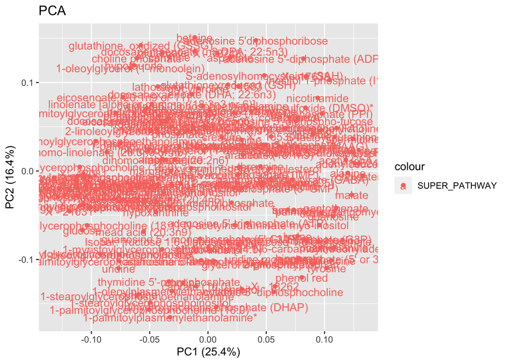

### modify_filter_samples

*Log text:*  
Filter samples: ~

*Log text:*  
Filter samples: outlier_univariate == FALSE

### plots_PCA

*Log text:*  
PCA, scores, labelby: , aes:

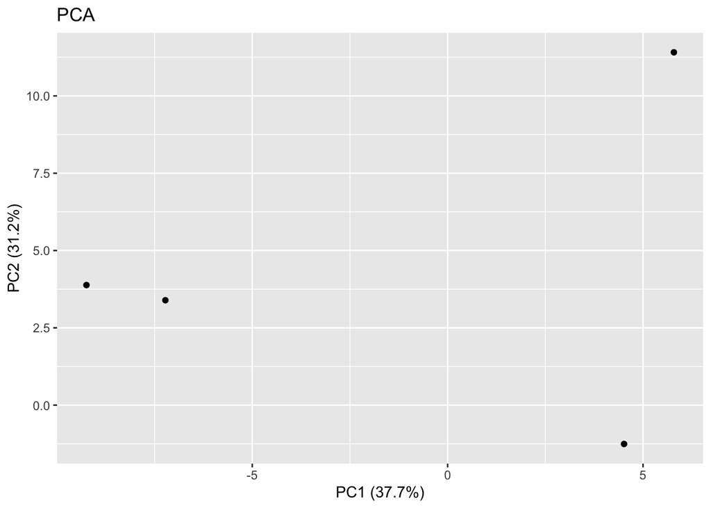